# regressao linear multivariada

Nazareno Andrade

# Os dados

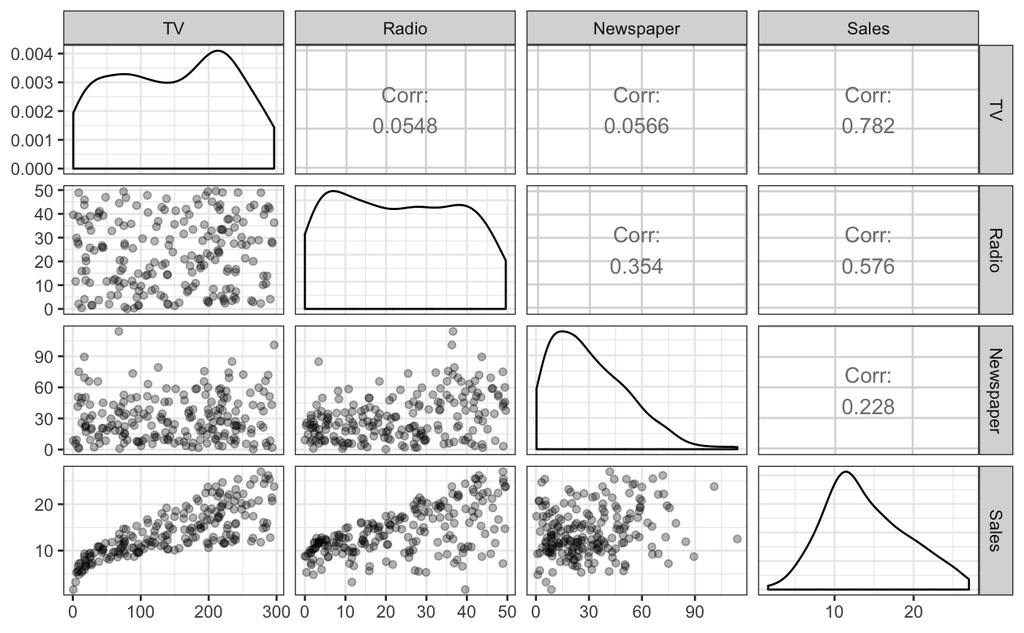

```r
advertising = read_csv("../dados/Advertising.csv") %>%
  rename(campaign = X1)
advertising %>%
  select(-campaign) %>%
  ggpairs(lower = list(continuous = wrap("points", alpha = 0.3)), progress = FALSE)
```

# Uma regressão linear simples

### Modelo da relação entre gasto com TV e vendas.

Linear direto com os dados.

```r
tv.model = lm(Sales ~ TV, data = advertising)
tidy(tv.model)
```

| term | estimate | std.error | statistic | p.value |
| --- | --- | --- | --- | --- |
| (Intercept) | 7.03259355 | 0.457842940 | 15.36028 | 1.40630e-35 |
| TV | 0.04753664 | 0.002690607 | 17.66763 | 1.46739e-42 |

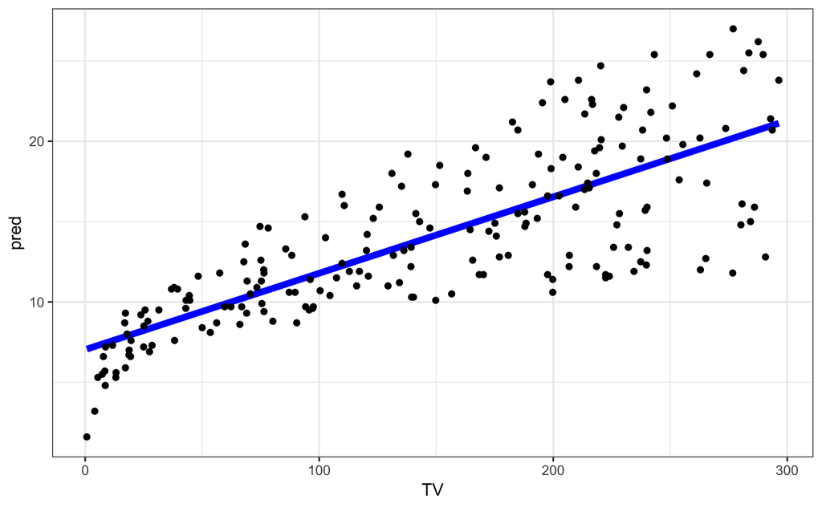

```r
adv_augmented = advertising %>%
  add_predictions(tv.model) %>%
  add_residuals(tv.model)
# Modelo x dados
adv_augmented %>%
  ggplot(aes(x = TV)) +
  geom_line(aes(y = pred), size = 2, colour = "blue") +
  geom_point(aes(y = Sales))
```

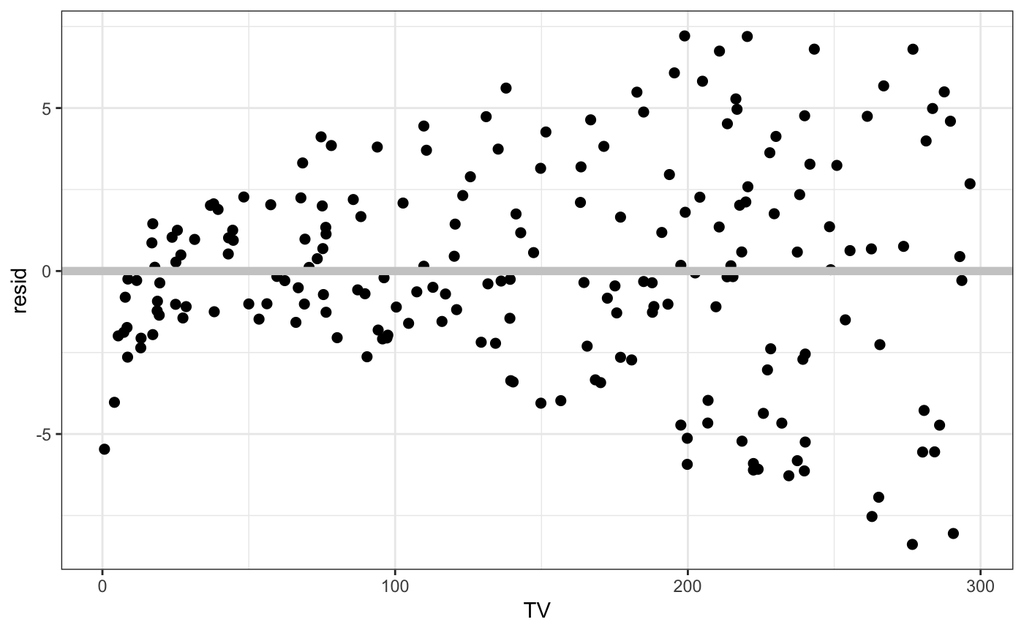

```r
# Resíduos x dados
adv_augmented %>%
  ggplot(aes(x = TV)) +
  geom_point(aes(y = resid), size = 2) +
  geom_ref_line(h = 0, colour = "grey80")
```

```r
tidy(tv.model, conf.int = TRUE)
```

| term | estimate | std.error | statistic | p.value | conf.low | conf.high |
| --- | --- | --- | --- | --- | --- | --- |
| (Intercept) | 7.03259355 | 0.457842940 | 15.36028 | 1.40630e-35 | 6.12971927 | 7.93546783 |
| TV | 0.04753664 | 0.002690607 | 17.66763 | 1.46739e-42 | 0.04223072 | 0.05284256 |

```r
glance(tv.model, conf.int = TRUE)
```

| r.squared | adj.r.squared | sigma | statistic | p.value | df | logLik | AIC | BIC | deviance | df.residual |
| --- | --- | --- | --- | --- | --- | --- | --- | --- | --- | --- |
| 0.6118751 | 0.6099148 | 3.258656 | 312.145 | 1.46739e-42 | 2 | -519.0457 | 1044.091 | 1053.986 | 2102.531 | 198 |

A função linear não se adequa lá muito bem. Outras que poderíamos usar:

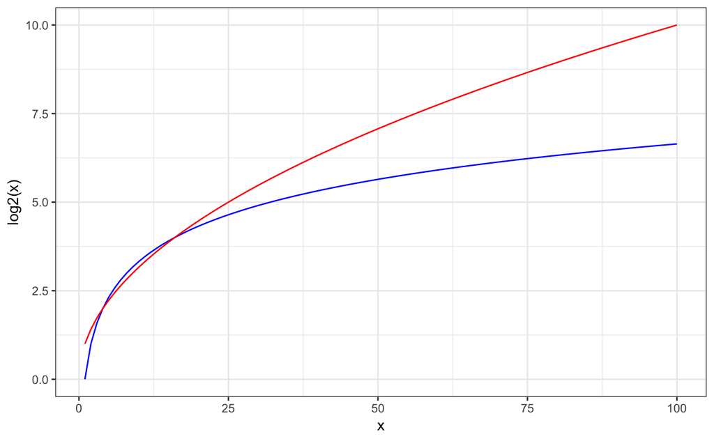

```r
d = tibble(x = 1:100)
d %>%
  ggplot(aes(x = x)) +
  geom_line(aes(y = log2(x)), color = "blue") +
  geom_line(aes(y = sqrt(x)), color = "red")
```

## Testando Transformações

`y ~ log(x)` ainda não parece linear, e tem heteroscedasticidade.

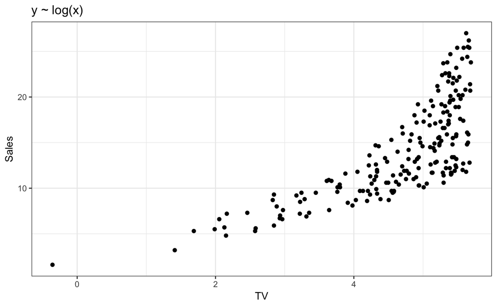

```r
advertising %>%
  mutate(TV = log(TV)) %>%
  ggplot(aes(x = TV)) +
  geom_point(aes(y = Sales)) +
  ggtitle("y ~ log(x)")
```

`log(y) ~ log(x)` faz a relação se parecer muito mais com uma relação linear.

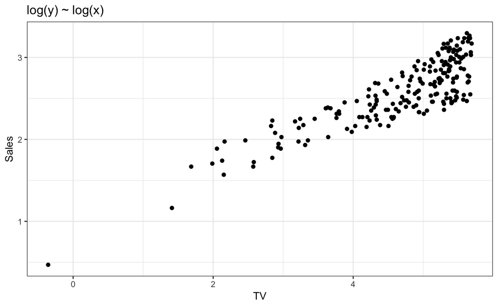

```r
advertising %>%
  mutate(Sales = log(Sales),
         TV = log(TV)) %>%
  ggplot(aes(x = TV)) +
  geom_point(aes(y = Sales)) +
  ggtitle("log(y) ~ log(x)")
```

## Usando a relação entre as variáveis transformadas para ajustar um modelo linear

```r
advertising  = advertising %>%
  mutate(TV2 = log2(TV),
         Sales2 = log2(Sales))
tv.model = lm(Sales2 ~ TV2, data = advertising)
```

Para visualizar o modelo, usarmeos um data frame com os dados originais e com as estimativas do modelo e resíduos para os valores nos dados.

```r
adv_augmented = advertising %>%
  add_predictions(tv.model) %>%
  add_residuals(tv.model)
```

Visualizando. Primeiro `log(Sales) ~ log(TV)`:

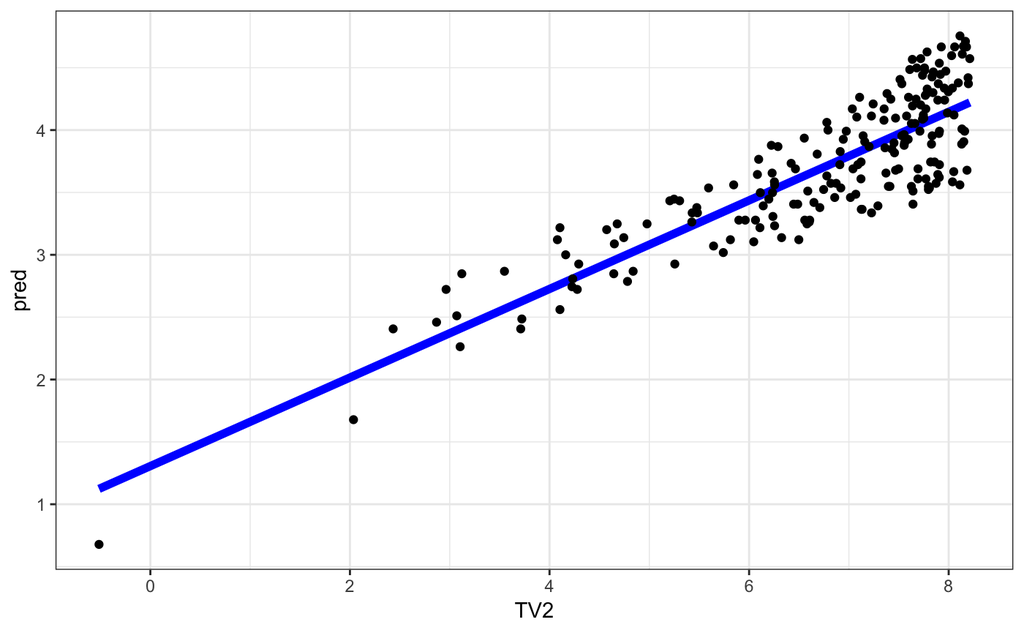

```r
# Modelo x dados
adv_augmented %>%
  ggplot(aes(x = TV2)) +
  geom_line(aes(y = pred), size = 2, colour = "blue") +
  geom_point(aes(y = Sales2))
```

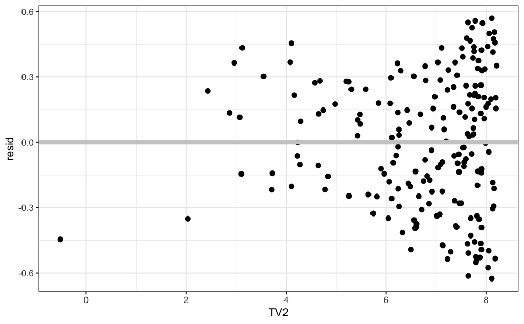

```r
# Resíduos x dados
adv_augmented %>%
  ggplot(aes(x = TV2)) +
  geom_point(aes(y = resid), size = 2) +
  geom_ref_line(h = 0, colour = "grey80")
```

E como é esse modelo?

```r
tidy(tv.model, conf.int = TRUE)
```

| term | estimate | std.error | statistic | p.value | conf.low | conf.high |
| --- | --- | --- | --- | --- | --- | --- |
| (Intercept) | 1.3059931 | 0.1025314 | 12.73750 | 1.550420e-27 | 1.1037995 | 1.5081868 |
| TV2 | 0.3550357 | 0.0148728 | 23.87148 | 3.505063e-60 | 0.3257063 | 0.3843652 |

```r
glance(tv.model, conf.int = TRUE)
```

| r.squared | adj.r.squared | sigma | statistic | p.value | df | logLik | AIC | BIC | deviance | df.residual |
| --- | --- | --- | --- | --- | --- | --- | --- | --- | --- | --- |
| 0.7421363 | 0.740834 | 0.3043208 | 569.8475 | 3.505063e-60 | 2 | -44.84811 | 95.69622 | 105.5912 | 18.33701 | 198 |

O modelo é $log_2(Sales) = 1.3 + 0.35*log_2(TV)$. Isso é equivalente a $2^{log_2(Sales)} = 2^{1.3 + 0.35*log_2(TV)}$ que equivale a $Sales = 2^{1.3}*TV^{0.35}$. Testando:

```r
## estimativa do modelo
p = predict(tv.model,
            data.frame(TV2 = log2(100)))
## Como o modelo estima log2(Sales), para ver Sales, fazemos o inverso de log2:
paste("Estimativa do modelo:", 2**p)
```

```
[1] "Estimativa do modelo: 12.6827833777741"
```

```r
## estimativa na mão
paste("Estimativa da fórmula:", (2**1.3059)*100**.355)
```

```
[1] "Estimativa da fórmula: 12.6798778935818"
```

Uma boa ideia é visualizar `Sales` em função de `TV`, ambas sem transformação. Repare que os ranges de TV e do eixo y estão ambos como nas variáveis originais. Estamos visualizando `2**pred` no eixo vertical para compensar o fato de que `pred`, vinda do modelo, é um valor estimado para `log2(Sales)`.

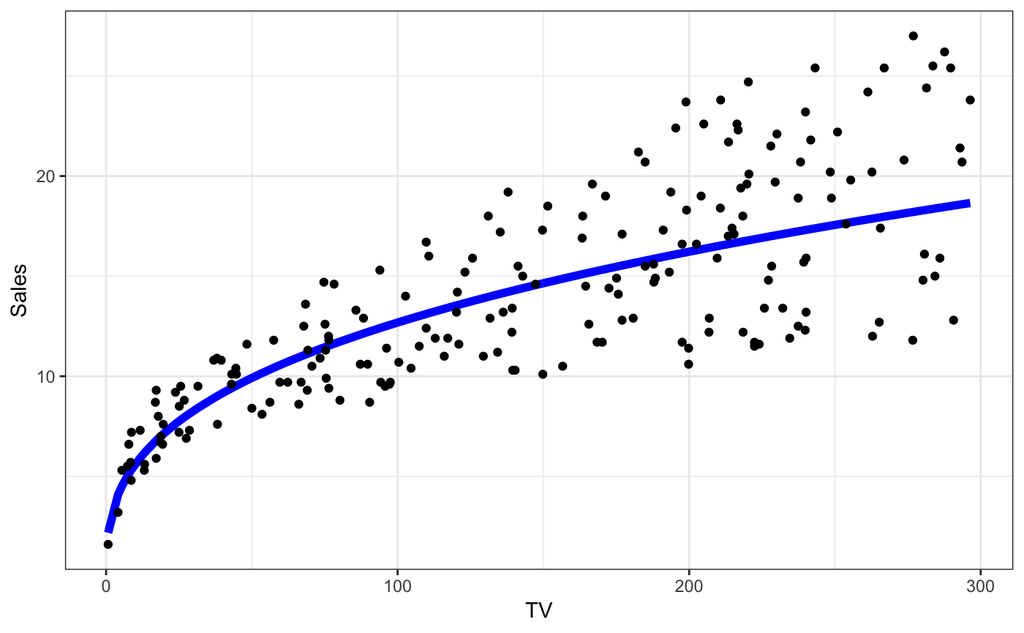

```r
adv_augmented %>%
  ggplot(aes(x = TV)) +
  geom_line(aes(y = 2**(pred)), size = 2, colour = "blue") +
  geom_point(aes(y = Sales)) +
  ylab("Sales")
```

# Colocando mais variáveis como preditoras

## Se colocarmos apenas `Radio`

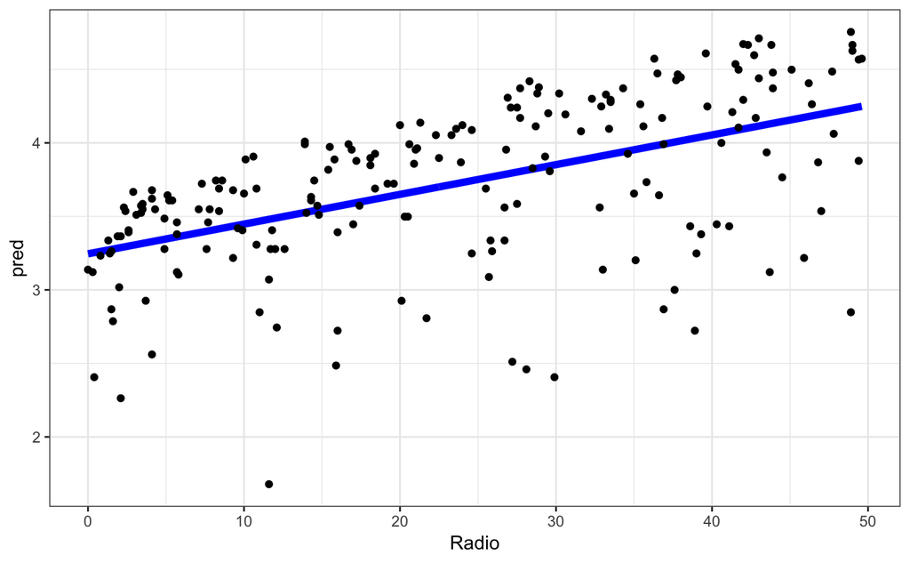

```r
radio.model = lm(Sales2 ~ Radio, data = advertising)
adv_augmented = advertising %>%
  add_predictions(radio.model) %>%
  add_residuals(radio.model)
# Modelo x dados
adv_augmented %>%
  ggplot(aes(x = Radio)) +
  geom_line(aes(y = pred), size = 2, colour = "blue") +
  geom_point(aes(y = Sales2))
```

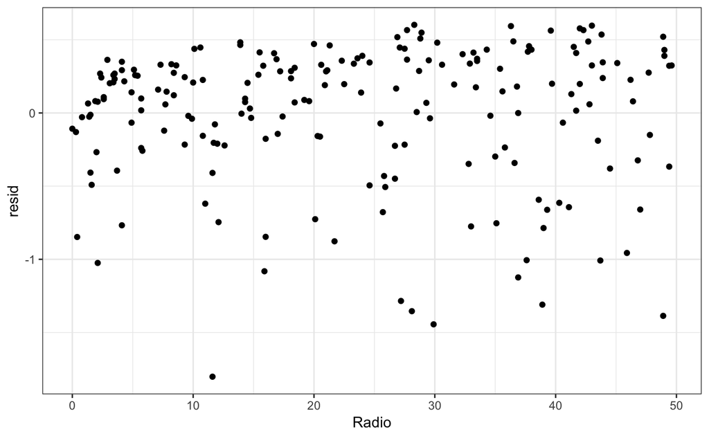

```r
adv_augmented %>%
  ggplot(aes(x = Radio)) +
  geom_point(aes(y = resid))
```

```r
tidy(radio.model, conf.int = TRUE)
```

| term | estimate | std.error | statistic | p.value | conf.low | conf.high |
| --- | --- | --- | --- | --- | --- | --- |
| (Intercept) | 3.24539598 | 0.062328983 | 52.06881 | 4.052621e-117 | 3.12247830 | 3.36831366 |
| Radio | 0.02022446 | 0.002266163 | 8.92454 | 3.122085e-16 | 0.01575541 | 0.02469351 |

```r
glance(radio.model, conf.int = TRUE)
```

[output not shown]

Ou apenas `Newspaper`

```r
np.model = lm(Sales ~ Newspaper, data = advertising)
tidy(np.model, conf.int = TRUE)
```

| term | estimate | std.error | statistic | p.value | conf.low | conf.high |
| --- | --- | --- | --- | --- | --- | --- |
| (Intercept) | 12.3514071 | 0.62142019 | 19.876096 | 4.713507e-49 | 11.12595560 | 13.57685854 |
| Newspaper | 0.0546931 | 0.01657572 | 3.299591 | 1.148196e-03 | 0.02200549 | 0.08738071 |

```r
glance(np.model, conf.int = TRUE)
```

| r.squared | adj.r.squared | sigma | statistic | p.value | df | logLik | AIC | BIC | deviance | df.residual |
| --- | --- | --- | --- | --- | --- | --- | --- | --- | --- | --- |
| 0.05212045 | 0.04733317 | 5.09248 | 10.8873 | 0.001148196 | 2 | -608.3357 | 1222.671 | 1232.566 | 5134.805 | 198 |

## Considerando os preditores ao mesmo tempo.

Lembre que isso é diferente de considerá-los separadamente.

Antes de fazer o ajuste do modelo, vamos tirar o ponto anômalo que dá um resíduo muito maior (em módulo) que todos os demais pontos:

```r
advertising = filter(advertising, TV > 3)
```

Agora, ajustando um modelo multivariado considerando efeitos de TV, Newspaper e Radio independentemente em Sales:

```r
multi = lm(Sales2 ~ TV2 + Newspaper + Radio, data = advertising)
adv_augmented = advertising %>%
  add_predictions(multi) %>%
  add_residuals(multi)
```

Precisamos visualizar os resíduos em função de cada preditor:

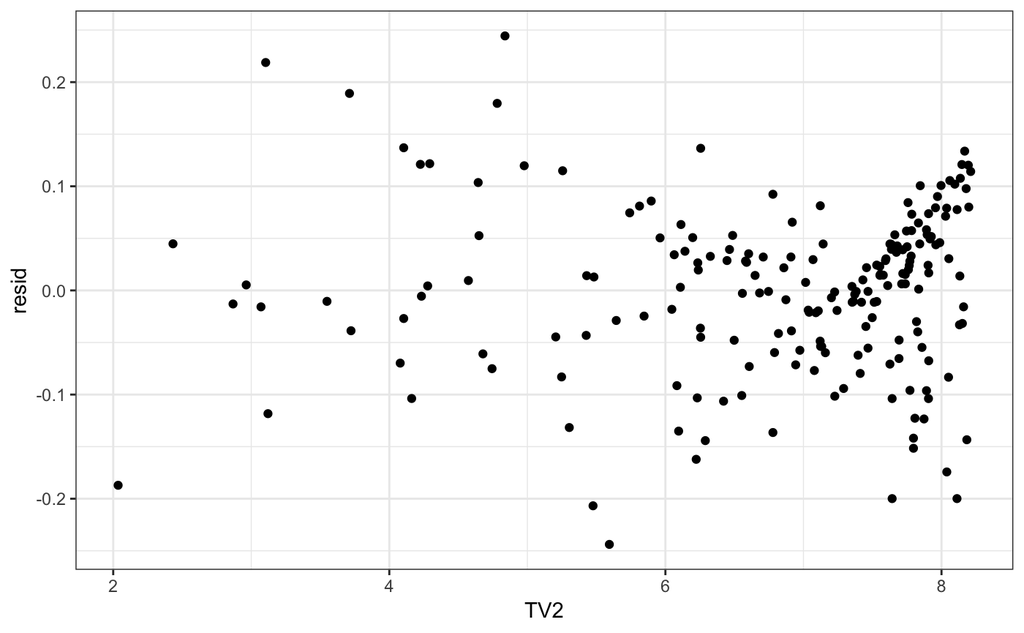

```r
adv_augmented %>%
  ggplot(aes(x = TV2)) +
  geom_point(aes(y = resid))
```

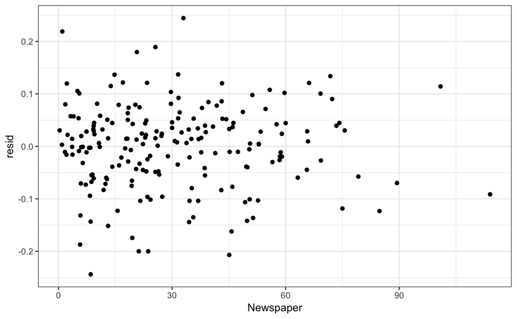

```r
adv_augmented %>%
  ggplot(aes(x = Newspaper)) +
  geom_point(aes(y = resid))
```

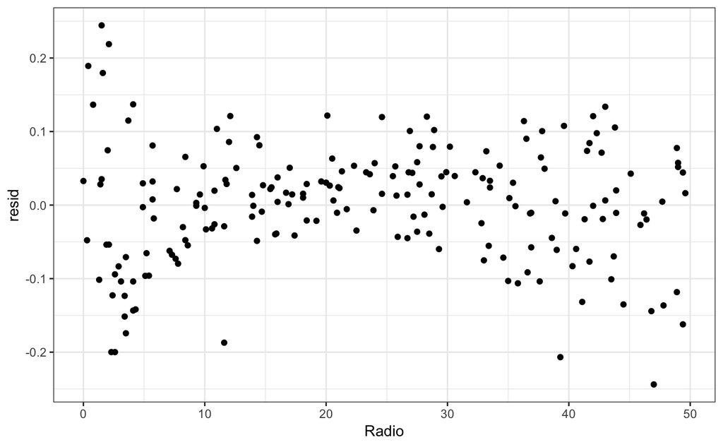

```r
adv_augmented %>%
  ggplot(aes(x = Radio)) +
  geom_point(aes(y = resid))
```

Como não há nada alarmante em termos de valores extremos, relações obviamente não-lineares e nem heteroscedasticidade, vamos examinar os coeficientes e o modelo. Os coeficientes e fit:

```r
tidy(multi, conf.int = TRUE) %>%
  select(-std.error, -p.value)
```

| term | estimate | statistic | conf.low | conf.high |
| --- | --- | --- | --- | --- |
| (Intercept) | 9.404084e-01 | 30.540483 | 0.8796799110 | 1.0011368780 |
| TV2 | 3.422674e-01 | 80.988759 | 0.3339326916 | 0.3506021960 |
| Newspaper | -6.915196e-05 | -0.244472 | -0.0006270147 | 0.0004887107 |
| Radio | 1.969082e-02 | 47.429707 | 0.0188720400 | 0.0205095920 |

```r
glance(multi)
```

| r.squared | adj.r.squared | sigma | statistic | p.value | df | logLik | AIC | BIC | deviance | df.residual |
| --- | --- | --- | --- | --- | --- | --- | --- | --- | --- | --- |
| 0.979442 | 0.9791258 | 0.08080811 | 3096.792 | 3.628406e-164 | 4 | 220.2715 | -430.543 | -414.0765 | 1.273341 | 195 |

## Visualizando o modelo multivariado

Caso apliquemos o modelo em todos os pontos de `advertising`, teremos várias estimativas para um mesmo valor de `Radio`, já que existem várias combinações de um dado valor dessa variável com as demais variáveis de entrada no modelo. Isso fica confuso muito fácil.

Para controlar que combinações de valores plotaremos precisamos *gerar o data frame de entrada para a visualização*:

```r
para_plotar_modelo = advertising %>%
  data_grid(TV2 = seq_range(TV2, 10), # Crie um vetor de 10 valores no range de TV2
            Radio = seq_range(Radio, 4), # Vetor de 4 valores no range de Radio
            Newspaper = seq_range(Newspaper, 3)) %>%
  add_predictions(multi)
glimpse(para_plotar_modelo)
```

```
Observations: 120
Variables: 4
$ TV2       <dbl> 2.035624, 2.035624, 2.035624, 2.035624, 2.035624, 2.035624, 2.035624, 2.035624...
$ Radio     <dbl> 0.00000, 0.00000, 0.00000, 16.53333, 16.53333, 16.53333, 33.06667, 33.06667, 3...
$ Newspaper <dbl> 0.30, 57.15, 114.00, 0.30, 57.15, 114.00, 0.30, 57.15, 114.00, 0.30, 57.15, 11...
$ pred      <dbl> 1.637115, 1.633184, 1.629253, 1.962670, 1.958739, 1.954808, 2.288225, 2.284294...
```

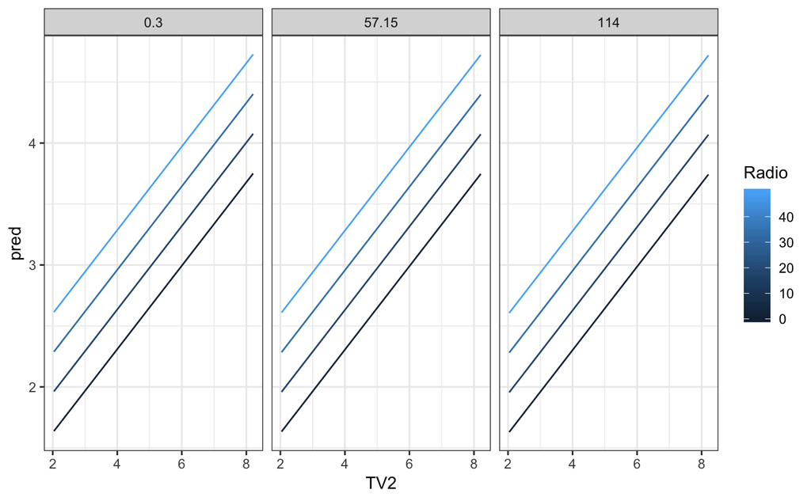

```r
para_plotar_modelo %>%
  ggplot(aes(x = TV2, y = pred)) +
  geom_line(aes(group = Radio, colour = Radio)) +
  facet_grid(. ~ Newspaper)
```

Converter para Sales é exponenciar Sales2. Caso queiramos vê-la em função de TV (e não TV2), exponenciamos TV2 também.

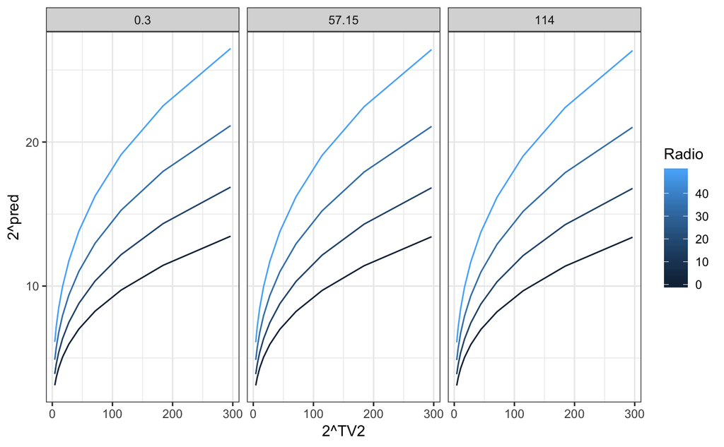

```r
para_plotar_modelo %>%
  ggplot(aes(x = 2**TV2, y = 2**pred)) +
  geom_line(aes(group = Radio, colour = Radio)) +
  facet_grid(. ~ Newspaper)
```

## Sobre modelos uni x multivariados

Repare na diferença nas significâncias dos preditores para os modelos univariados e para o multivariado.

Algumas perguntas que queremos responder:

- O modelo considerando esses preditores é útil em explicar a resposta?
- Todos os preditores contribuem para explicar a resposta, ou apenas algum?
- Quão bem ajustado aos dados o modelo está?

# Interações não aditivas

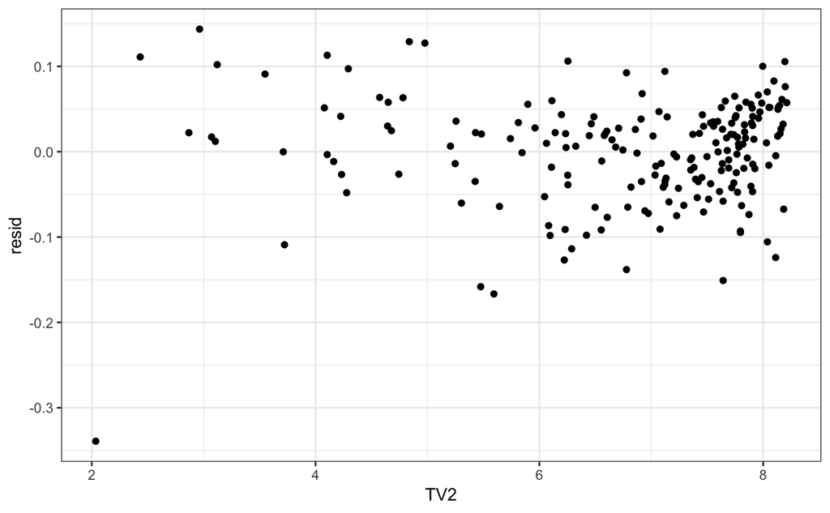

```r
multi = lm(Sales2 ~ TV2 + Radio + Newspaper + Radio*TV2 + Radio*Newspaper, data = advertising)
adv_augmented = advertising %>%
  add_predictions(multi) %>%
  add_residuals(multi)
adv_augmented %>%
  ggplot(aes(x = TV2)) +
  geom_point(aes(y = resid))
```

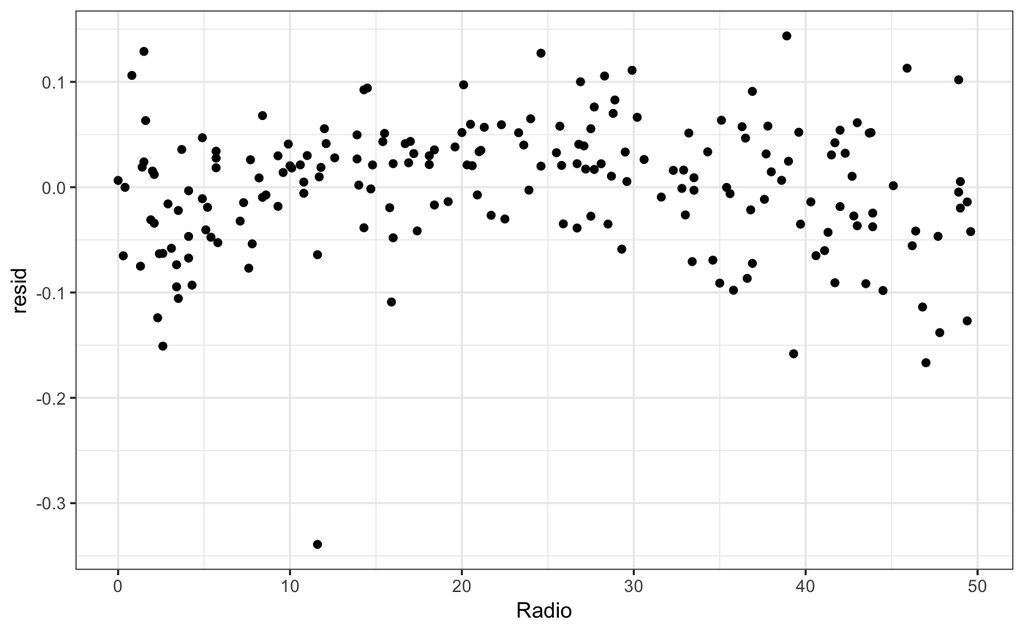

```r
adv_augmented %>%
  ggplot(aes(x = Radio)) +
  geom_point(aes(y = resid))
```

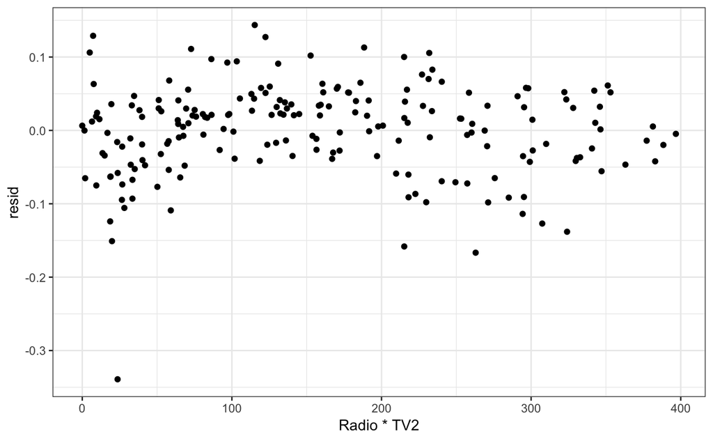

```r
adv_augmented %>%
  ggplot(aes(x = Radio*TV2)) +
  geom_point(aes(y = resid))
```

```r
tidy(multi, conf.int = TRUE)
```

| term | estimate | std.error | statistic | p.value | conf.low | conf.high |
| --- | --- | --- | --- | --- | --- | --- |
| (Intercept) | 1.361507e+00 | 4.511479e-02 | 30.1787284 | 5.234863e-75 | 1.272526e+00 | 1.4504882945 |
| TV2 | 2.796324e-01 | 6.432583e-03 | 43.4712427 | 1.222659e-101 | 2.669452e-01 | 0.2923195590 |
| Radio | 2.202682e-03 | 1.635482e-03 | 1.3468090 | 1.796211e-01 | -1.023031e-03 | 0.0054283958 |
| Newspaper | 8.034188e-05 | 5.093564e-04 | 0.1577321 | 8.748328e-01 | -9.242780e-04 | 0.0010849617 |
| TV2:Radio | 2.555385e-03 | 2.250150e-04 | 11.3565123 | 3.206528e-23 | 2.111581e-03 | 0.0029991893 |
| Radio:Newspaper | 2.187391e-06 | 1.571333e-05 | 0.1392060 | 8.894325e-01 | -2.880452e-05 | 0.0000331793 |

```r
glance(multi)
```

| r.squared | adj.r.squared | sigma | statistic | p.value | df | logLik | AIC | BIC | deviance | df.residual |
| --- | --- | --- | --- | --- | --- | --- | --- | --- | --- | --- |
| 0.9876777 | 0.9873585 | 0.06288526 | 3093.941 | 4.028832e-182 | 6 | 271.1996 | -528.3993 | -505.3462 | 0.7632293 | 193 |

```r
#autoplot(multi)
```

Qual o intervalo de confiança da estimativa de `Sales2` para uma certa combinação de valores de investimento em Rádio, TV e Jornal impresso?

```r
predict(multi,
        data.frame(Radio = 10e3, TV2 = log2(20e3), Newspaper = 0),
        interval = "predict")
```

```
       fit     lwr      upr
1 392.4897 357.576 427.4034
```